# Data Reanalysis Assignment

# Replication 1: Figure 1 (Descriptive)

First I replicated Figure 1 from the paper. This figure shows the distribution of matings with respect to male type and female ovulatory status.

First I created 3 variables of female mating type. Each female was either pregnant, in the periovulatory period, or neither (non-periovulatory).

```r
nonPOP <- filter(d, preg == "0" & POP == "0")
nonPOP #matings with females not in periovulatory period; currently cycling
```

```
##    Date day year    year2 DateSPSS      Name     Name2 Record.
## 1 33878 275   92 92.75291  10/1/92   Marissa   Marissa      20
## 2 34061  93   93 93.25394   4/3/93   Marissa   Marissa      22
## 3 34340   7   94 94.01780   1/7/94 Elizabeth Elizabeth      31
## 4 34343  10   94 94.02601  1/10/94    Zarina    Zarina      35
## 5 34344  11   94 94.02875  1/11/94    Zarina    Zarina      41
## 6 36210  50   99 99.13758  2/19/99   Kristen   Kristen      78
##   TypeofInteraction FemaleAgeclass FemaleMotherClass OffspringClass
## 1          Mating 1   Adult Female            Mother     Over 4 yrs
## 2          Mating 1   Adult Female            Mother     Over 4 yrs
## 3          Mating 1   Adult Female            Mother     Inf no juv
## 4          Mating 1   Adult Female            Mother     Over 4 yrs
## 5          Mating 1   Adult Female            Mother     Over 4 yrs
## 6          Mating 1   Adult Female            Mother    Inf ind juv
##   ObservedReproductiveStatus EndocrineStatusHormones CyclePhaseHormones
```

[output cut: 118 more lines]

```r
pregnant <- filter(d, preg == "1")
pregnant #matings with pregnant females
```

```
##    Date day year    year2 DateSPSS     Name   Name2 Record.
## 1 33193 321   90 90.87748 11/17/90  Kristen Kristen       7
## 2 33194 322   90 90.88022 11/18/90  Kristen Kristen       8
## 3 33194 322   90 90.88022 11/18/90  Kristen Kristen       9
## 4 33248  10   91 91.02806  1/10/91 Female A Afemale      10
## 5 33257  19   91 91.05270  1/19/91     Beth    Beth      11
## 6 35764 335   97 97.91650  12/1/97    Kayla   Kayla      73
## 7 35765 336   97 97.91923  12/2/97    Kayla   Kayla      75
## 8 35766 337   97 97.92197  12/3/97    Kayla   Kayla      76
##   TypeofInteraction FemaleAgeclass FemaleMotherClass OffspringClass
## 1          Mating 1   Adult Female            Mother     Over 4 yrs
## 2          Mating 1   Adult Female            Mother     Over 4 yrs
## 3          Mating 2   Adult Female            Mother     Over 4 yrs
## 4          Mating 1   Adult Female        Non-mother      No infant
## 5          Mating 1   Adult Female        Non-mother      No infant
```

[output cut: 156 more lines]

```r
POP <- filter(d, POP == "1")
POP #matings with females in periovulatory period
```

```
##    Date day year    year2 DateSPSS    Name   Name2 Record.
## 1 34318 350   93 93.95756 12/16/93 Marissa Marissa      26
## 2 34318 350   93 93.95756 12/16/93 Marissa Marissa      27
## 3 34340   7   94 94.01780   1/7/94 Marissa Marissa      30
## 4 34341   8   94 94.02053   1/8/94 Marissa Marissa      32
## 5 34343  10   94 94.02601  1/10/94 Marissa Marissa      39
## 6 34347  14   94 94.03696  1/14/94  Zarina  Zarina      42
## 7 34349  16   94 94.04244  1/16/94  Zarina  Zarina      45
##   TypeofInteraction FemaleAgeclass FemaleMotherClass OffspringClass
## 1          Mating 1   Adult Female            Mother     Over 4 yrs
## 2          Mating 2   Adult Female            Mother     Over 4 yrs
## 3          Mating 1   Adult Female            Mother     Over 4 yrs
## 4          Mating 1   Adult Female            Mother     Over 4 yrs
## 5          Mating 1   Adult Female            Mother     Over 4 yrs
## 6          Mating 1   Adult Female            Mother     Over 4 yrs
```

[output cut: 129 more lines]

(Note: when knitting the file I continued to get an error message in each chunk until I added “eval = FALSE” at the top of the chunk. I couldn’t figure out why this was happening, so for each chunk I wanted to show the output of, I added a new chunk below it with the same output variable but “echo = FALSE” at the top. This allows just the output to be shown, without the code in the extra chunk.)

Next I created 6 more variables which will serve as each entry of the replicated bar plot. The 3 female ovulatory statuses stay the same, though they are divided bewtween those who mated with prime males and those who mated with non-prime males (either unflanged or past-prime). For each variable I also counted the number of occurences of the type of mating by counting the number of rows.

```r
nonPOP_nonprime <- filter(nonPOP, prime == "0")
nonPOP_nonprime
```

```
##    Date day year    year2 DateSPSS      Name     Name2 Record.
## 1 33878 275   92 92.75291  10/1/92   Marissa   Marissa      20
## 2 34061  93   93 93.25394   4/3/93   Marissa   Marissa      22
## 3 34340   7   94 94.01780   1/7/94 Elizabeth Elizabeth      31
## 4 34343  10   94 94.02601  1/10/94    Zarina    Zarina      35
## 5 34344  11   94 94.02875  1/11/94    Zarina    Zarina      41
## 6 36210  50   99 99.13758  2/19/99   Kristen   Kristen      78
##   TypeofInteraction FemaleAgeclass FemaleMotherClass OffspringClass
## 1          Mating 1   Adult Female            Mother     Over 4 yrs
## 2          Mating 1   Adult Female            Mother     Over 4 yrs
## 3          Mating 1   Adult Female            Mother     Inf no juv
## 4          Mating 1   Adult Female            Mother     Over 4 yrs
## 5          Mating 1   Adult Female            Mother     Over 4 yrs
## 6          Mating 1   Adult Female            Mother    Inf ind juv
##   ObservedReproductiveStatus EndocrineStatusHormones CyclePhaseHormones
```

[output cut: 118 more lines]

```r
totalmatings1 <- length(attributes(nonPOP_nonprime)$row.names)
```

```r
nonPOP_prime <- filter(nonPOP, prime == "1")
nonPOP_prime
```

```
##  [1] Date
##  [2] day
##  [3] year
##  [4] year2
##  [5] DateSPSS
##  [6] Name
##  [7] Name2
##  [8] Record.
##  [9] TypeofInteraction
## [10] FemaleAgeclass
## [11] FemaleMotherClass
## [12] OffspringClass
## [13] ObservedReproductiveStatus
## [14] EndocrineStatusHormones
## [15] CyclePhaseHormones
```

[output cut: 59 more lines]

```r
totalmatings2 <- length(attributes(nonPOP_prime)$row.names)
```

```r
pregnant_nonprime <- filter(pregnant, prime == "0")
pregnant_nonprime
```

```
##    Date day year    year2 DateSPSS     Name   Name2 Record.
## 1 33193 321   90 90.87748 11/17/90  Kristen Kristen       7
## 2 33194 322   90 90.88022 11/18/90  Kristen Kristen       8
## 3 33194 322   90 90.88022 11/18/90  Kristen Kristen       9
## 4 33248  10   91 91.02806  1/10/91 Female A Afemale      10
## 5 33257  19   91 91.05270  1/19/91     Beth    Beth      11
##   TypeofInteraction FemaleAgeclass FemaleMotherClass OffspringClass
## 1          Mating 1   Adult Female            Mother     Over 4 yrs
## 2          Mating 1   Adult Female            Mother     Over 4 yrs
## 3          Mating 2   Adult Female            Mother     Over 4 yrs
## 4          Mating 1   Adult Female        Non-mother      No infant
## 5          Mating 1   Adult Female        Non-mother      No infant
##   ObservedReproductiveStatus EndocrineStatusHormones CyclePhaseHormones
## 1                   Pregnant
## 2                   Pregnant
```

[output cut: 93 more lines]

```r
totalmatings3 <- length(attributes(pregnant_nonprime)$row.names)
```

```r
pregnant_prime <- filter(pregnant, prime == "1")
pregnant_prime
```

```
##    Date day year    year2 DateSPSS  Name Name2 Record. TypeofInteraction
## 1 35764 335   97 97.91650  12/1/97 Kayla Kayla      73          Mating 1
## 2 35765 336   97 97.91923  12/2/97 Kayla Kayla      75          Mating 1
## 3 35766 337   97 97.92197  12/3/97 Kayla Kayla      76          Mating 1
##   FemaleAgeclass FemaleMotherClass OffspringClass
## 1   Adult Female        Non-mother      No infant
## 2   Adult Female        Non-mother      No infant
## 3   Adult Female        Non-mother      No infant
##   ObservedReproductiveStatus EndocrineStatusHormones CyclePhaseHormones
## 1                   Pregnant
## 2                   Pregnant
## 3                   Pregnant                 cycling           Not sure
##   ReproductiveStatus       Endo2    Endo3    Endo4    Endo5    Endo6
## 1           Pregnant non-cycling Pregnant Pregnant Pregnant Pregnant
## 2           Pregnant non-cycling Pregnant Pregnant Pregnant Pregnant
```

[output cut: 57 more lines]

```r
totalmatings4 <- length(attributes(pregnant_prime)$row.names)
```

```r
POP_nonprime <- filter(POP, prime == "0")
POP_nonprime
```

```
##    Date day year    year2 DateSPSS   Name  Name2 Record. TypeofInteraction
## 1 34347  14   94 94.03696  1/14/94 Zarina Zarina      42          Mating 1
##   FemaleAgeclass FemaleMotherClass OffspringClass
## 1   Adult Female            Mother     Over 4 yrs
##   ObservedReproductiveStatus EndocrineStatusHormones CyclePhaseHormones
## 1
##   ReproductiveStatus Endo2   Endo3 Endo4 Endo5 Endo6 Endo7 Endo8
## 1            Cycling   POP Cycling   POP   POP   POP   POP   POP
##   Pregnantvs.nonpregnant E1CmgCr PDGmgCr CommentMET
## 1               Non-Preg      NA      NA         NA
##                          EndorineComment SocialInteraction
## 1 Ovulation occurs between 1/16 and 1/22                 Y
##   InteractionwithMale Mating NearMating Consortship ObservationMinutes
## 1                   Y      Y          N           Y                795
##   FollowType FollowTypeII Lengthofmating PelvicThrusts  Male MaletypeI
## 1    F  full            F       0.004086           261 Roman   Flanged
##   MaleTypeII MaleTypeIII MatingTypeExcel MatingTypePercent
## 1 Past Prime   Non-Prime          Forced            Forced
##   MatingTypePercentII MatingTypeII MatingTypeIII Matingtypequestionable
## 1              Forced       Forced      Resisted                     No
##   TotalnonresistantProceptiveandResistanceBehaviors
## 1                                                 2
##   NonResistantBeforeBehaviors NonResistantDuringBehaviors
## 1                          NA                          NA
##   Totalnonresistantbehaviors NonresistantBehaviors ProceptiveBehaviors
## 1                         NA                     0                  NA
##   ProceptiveBehaviors_A TotalunresistedandProcepetivebehaviors
## 1                     0                                     NA
##   unresistedandProcepetivebehaviors ResistantBeforeBehaviors
## 1                                 0                       NA
##   BeforeBehaviors ResistantDuringBehaviors DuringBehaviors
## 1               0                        2               1
##   TotalResistantBehaviors ResistantBehaviors AttractionBehaviors Mating01
## 1                       2                  1                   2        1
##   POP preg lact prime past unflanged included endomiss
## 1   1    0    0     0    1         0        1        0
```

```r
totalmatings5 <- length(attributes(POP_nonprime)$row.names)
```

```r
POP_prime <- filter(POP, prime == "1")
POP_prime
```

```
##    Date day year    year2 DateSPSS    Name   Name2 Record.
## 1 34318 350   93 93.95756 12/16/93 Marissa Marissa      26
## 2 34318 350   93 93.95756 12/16/93 Marissa Marissa      27
## 3 34340   7   94 94.01780   1/7/94 Marissa Marissa      30
## 4 34341   8   94 94.02053   1/8/94 Marissa Marissa      32
## 5 34343  10   94 94.02601  1/10/94 Marissa Marissa      39
## 6 34349  16   94 94.04244  1/16/94  Zarina  Zarina      45
##   TypeofInteraction FemaleAgeclass FemaleMotherClass OffspringClass
## 1          Mating 1   Adult Female            Mother     Over 4 yrs
## 2          Mating 2   Adult Female            Mother     Over 4 yrs
## 3          Mating 1   Adult Female            Mother     Over 4 yrs
## 4          Mating 1   Adult Female            Mother     Over 4 yrs
## 5          Mating 1   Adult Female            Mother     Over 4 yrs
## 6          Mating 1   Adult Female            Mother     Over 4 yrs
##   ObservedReproductiveStatus EndocrineStatusHormones CyclePhaseHormones
```

[output cut: 111 more lines]

```r
totalmatings6 <- length(attributes(POP_prime)$row.names)
```

I then created a vector of each of the values of occurences.

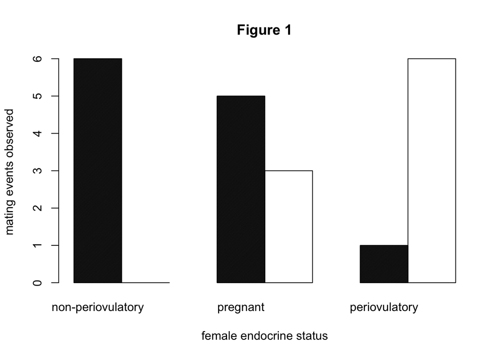

```r
v <- c(totalmatings1, totalmatings2, totalmatings3, totalmatings4, totalmatings5, totalmatings6)

barplot(v, main = "Figure 1", xlab = "female endocrine status", ylab = "mating events observed", names.arg = c("non-periovulatory","non-periovulatory","pregnant","pregnant", "periovulatory", "periovulatory"), col = "black", density = c(100, 0, 100, 0, 100, 0), space = c(1, 0, 1, 0, 1, 0))
```

This is what the original figure from the paper looked like:

[figure not shown]

They are the same!

It is possible that there is a more concise way to replicate this figure, though this way seemed the most logical to me, given the format of the data.

# Replication 2: Figure 2 (Descriptive)

The second figure in the paper shows the distribution of female encounters with males, with respect to male type and female ovulatory status. I planned to use a similar method to create this figure as I did for the first one (the dependent variable is now ‘encounters observed’), though I ran into a lot of problems.

I recieved this dataset from the professor who is first author on this paper. She did not have the original files, so she reached out to the author who ran all the statistics for the paper. He emailed her zipped folders of all of the old versions of the dataset that he had. She then forwarded these folders to me, which contained hundreds of different documents which spanned the course of nearly 3 years. Unfortunately, all the observation data was spread out between different files which led to confusion. Additionally, the same writing conventions were not used throughout all the daat. For example, some variables were recorded as full words like “Prime” and “Nonprime” , while others were recorded as binary numbers “0” and “1”.

To begin the second replication, I first converted another SPSS file into csv format and loaded it in to R. This file contains all 2460 orangutan follows.

```r
# getting the data into R
library(curl)
f2 <- curl("https://raw.githubusercontent.com/natalierobinson96/data-reanalysis-assignment/master/interactions.csv")
d2 <- read.csv(f2, header = TRUE, sep = ",")
head(d2)
```

```
##    Date day year    year2   DateSPSS    Name   Name2 Record.
## 1 34397  64   94 94.17385 03/05/1994 Marissa Marissa     959
## 2 34398  65   94 94.17659 03/06/1994 Marissa Marissa     961
## 3 34504 171   94 94.46680 06/20/1994    Abby    Abby    1107
## 4 34505 172   94 94.46954 06/21/1994    Abby    Abby    1110
## 5 34506 173   94 94.47228 06/22/1994    Abby    Abby    1113
## 6 34507 174   94 94.47502 06/23/1994    Abby    Abby    1116
##   TypeofInteraction FemaleAgeclass FemaleMotherClass OffspringClass
## 1                     Adult Female            Mother     Over 4 yrs
## 2                     Adult Female            Mother     Over 4 yrs
## 3                     Adult Female            Mother     Over 4 yrs
## 4                     Adult Female            Mother     Over 4 yrs
## 5                     Adult Female            Mother     Over 4 yrs
## 6                     Adult Female            Mother     Over 4 yrs
##   ObservedReproductiveStatus EndocrineStatusHormones CyclePhaseHormones
```

[output cut: 111 more lines]

Next I created a new dataframe which only includes the observation entries (in which a male and female interacted with each other) which were included in the final analysis (in which both male and female reproductive status were known):

```r
d2 <- filter(d2, InteractionwithMale == "Y")
d2 <- filter(d2, included == "1")
head(d2)
```

```
##    Date day year    year2   DateSPSS        Name       Name2 Record.
## 1 34343  10   94 94.02601 01/10/1994 AF10Jan98\v AF10Jan98\v      36
## 2 34343  10   94 94.02601 01/10/1994 AF10Jan98\v AF10Jan98\v      37
## 3 33168 296   90 90.80903 10/23/1990    Betina A      Betina     100
## 4 34338   5   94 94.01232 01/05/1994    Betina Q      Betina     867
## 5 34340   7   94 94.01780 01/07/1994    Betina P      Betina     875
## 6 34341   8   94 94.02053 01/08/1994    Betina P      Betina     877
##   TypeofInteraction FemaleAgeclass FemaleMotherClass OffspringClass
## 1          Mating 1   Adult Female        Non-mother      No infant
## 2          Mating 2   Adult Female        Non-mother      No infant
## 3                     Adult Female        Non-mother      No infant
## 4       Consortship   Adult Female            Mother     Over 4 yrs
## 5       Consortship   Adult Female            Mother     Over 4 yrs
## 6                     Adult Female            Mother     Over 4 yrs
##   ObservedReproductiveStatus EndocrineStatusHormones CyclePhaseHormones
```

[output cut: 111 more lines]

This contains 331 observations, however, the paper states that only 153 encounters were included in the analysis. I continued on anyway.

As before, I created the 3 categories of female endocrine status:

```r
nonPOP <- filter(d2, lact == "1")
head(nonPOP) #matings with females not in periovulatory period; currently cycling
```

```
##    Date day year    year2   DateSPSS      Name     Name2 Record.
## 1 33256  18   91 91.04997 01/18/1991    Anissa    Anissa     173
## 2 33953 350   92 92.95825 12/15/1992      Beth      Beth     542
## 3 34007  39   93 93.10609 02/08/1993  Betina J    Betina      21
## 4 33167 295   90 90.80630 10/22/1990     Celia     Celia      99
## 5 34131 163   93 93.44559 06/12/1993 Elizabeth Elizabeth      23
## 6 33234 362   90 90.98973 12/28/1990 Elizabeth Elizabeth     160
##   TypeofInteraction FemaleAgeclass FemaleMotherClass OffspringClass
## 1                     Adult Female            Mother     Inf no juv
## 2                     Adult Female            Mother     Inf no juv
## 3         Attempt 1   Adult Female            Mother     Inf no juv
## 4         Encounter   Adult Female            Mother     Inf no juv
## 5         Attempt 1   Adult Female            Mother     Inf no juv
## 6       Consortship   Adult Female            Mother    Inf ind juv
##   ObservedReproductiveStatus EndocrineStatusHormones CyclePhaseHormones
```

[output cut: 111 more lines]

```r
pregnant <- filter(d2, preg == "1")
head(pregnant) #matings with pregnant females
```

```
##    Date day year    year2   DateSPSS     Name   Name2 Record.
## 1 33248  10   91 91.02806 01/10/1991 Female A Afemale      10
## 2 33247   9   91 91.02533 01/09/1991 Female A Afemale     169
## 3 33257  19   91 91.05270 01/19/1991     Beth    Beth      11
## 4 33261  23   91 91.06366 01/23/1991     Beth    Beth     182
## 5 33292  54   91 91.14853 02/23/1991     Beth    Beth     221
## 6 33293  55   91 91.15127 02/24/1991     Beth    Beth     223
##   TypeofInteraction FemaleAgeclass FemaleMotherClass OffspringClass
## 1          Mating 1   Adult Female        Non-mother      No infant
## 2       Consortship   Adult Female        Non-mother      No infant
## 3          Mating 1   Adult Female        Non-mother      No infant
## 4       Consortship   Adult Female        Non-mother      No infant
## 5       Consortship   Adult Female        Non-mother      No infant
## 6       Consortship   Adult Female        Non-mother      No infant
##   ObservedReproductiveStatus EndocrineStatusHormones CyclePhaseHormones
```

[output cut: 111 more lines]

```r
POP <- filter(d2, POP == "1")
head(POP) #matings with females in periovulatory period
```

```
##    Date day year    year2   DateSPSS    Name   Name2 Record.
## 1 34297 329   93 93.90007 11/25/1993 Kristen Kristen     797
## 2 34299 331   93 93.90554 11/27/1993 Kristen Kristen     806
## 3 33502 264   91 91.72348 09/21/1991 Marissa Marissa      19
## 4 34318 350   93 93.95756 12/16/1993 Marissa Marissa      26
## 5 34318 350   93 93.95756 12/16/1993 Marissa Marissa      27
## 6 34340   7   94 94.01780 01/07/1994 Marissa Marissa      29
##   TypeofInteraction FemaleAgeclass FemaleMotherClass OffspringClass
## 1                     Adult Female            Mother    Inf ind juv
## 2                     Adult Female            Mother    Inf ind juv
## 3       Consortship   Adult Female            Mother     Over 4 yrs
## 4          Mating 1   Adult Female            Mother     Over 4 yrs
## 5          Mating 2   Adult Female            Mother     Over 4 yrs
## 6         Attempt 1   Adult Female            Mother     Over 4 yrs
##   ObservedReproductiveStatus EndocrineStatusHormones CyclePhaseHormones
```

[output cut: 118 more lines]

I created 6 more variables which serve as each entry of the replicated bar plot. The 3 female ovulatory statuses stay the same, though they are divided bewtween those who encountered prime males and those who encountered non-prime males (either unflanged or past-prime). For each variable I also counted the number of occurences of encounters by counting the number of rows. This is the same as what I did in the initial replication.

```r
nonPOP_nonprime <- filter(nonPOP, prime == "0")
totalmatings1 <- length(attributes(nonPOP_nonprime)$row.names)
```

```r
nonPOP_prime <- filter(nonPOP, prime == "1")
totalmatings2 <- length(attributes(nonPOP_prime)$row.names)
```

```r
pregnant_nonprime <- filter(pregnant, prime == "0")
totalmatings3 <- length(attributes(pregnant_nonprime)$row.names)
```

```r
pregnant_prime <- filter(pregnant, prime == "1")
totalmatings4 <- length(attributes(pregnant_prime)$row.names)
```

```r
POP_nonprime <- filter(POP, prime == "0")
totalmatings5 <- length(attributes(POP_nonprime)$row.names)
```

```r
POP_prime <- filter(POP, prime == "1")
totalmatings6 <- length(attributes(POP_prime)$row.names)
```

I then created a vector of each of the values of occurences.

```r
v2 <- c(totalmatings1, totalmatings2, totalmatings3, totalmatings4, totalmatings5, totalmatings6)

barplot(v2, main = "Figure 2", xlab = "female endocrine status", ylab = "encounters observed", names.arg = c("non-periovulatory","non-periovulatory","pregnant","pregnant", "periovulatory", "periovulatory"), col = "black", density = c(100, 0, 100, 0, 100, 0), space = c(1, 0, 1, 0, 1, 0))
```

[output not shown]

This is what the figure from the paper looks like:

[figure not shown]

This replication did not turn out the same as the original figure. The “pregnant” and “periovulatory” categories look correct, though the values for the “non-periovulatory” category are too low. Unsure how to fix this, I tried using a different file, which contained a shortened version of the interaction data.

I loaded in the other converted file and created a new dataframe which only includes the observations which are in the final analysis:

```r
# getting the data into R
library(curl)
f2 <- curl("https://raw.githubusercontent.com/natalierobinson96/data-reanalysis-assignment/master/interactions%20(short).csv")
d2 <- read.csv(f2, header = TRUE, sep = ",")
d2 <- filter(d2, InteractionwithMale == "Y")
head(d2)
```

```
##    Date     Name  Name2 Record.  TypeofInteraction FemaleAgeclass
## 1 34183 Betina O Betina     668                       Adol Female
## 2 34184 Betina O Betina     670        Consortship    Adol Female
## 3 34337 Betina P Betina     862                      Adult Female
## 4 34339 Betina P Betina     871        Consortship   Adult Female
## 5 35529    Ceska  Ceska      69 Sexual Interaction   Adult Female
## 6 35529    Ceska  Ceska    2858          Encounter   Adult Female
##   FemaleMotherClass OffspringClass ObservedReproductiveStatus
## 1       Adol Female
## 2       Adol Female
## 3            Mother
## 4            Mother
## 5            Mother     Inf no juv
## 6            Mother     Inf no juv
##   EndocrineStatusHormones CyclePhaseHormones ReproductiveStatus   Endo2
```

[output cut: 552 more lines]

This file already had the interactions divided into columns of the 6 categories for the barplot, so I filtered these out.

```r
nonPOP_nonprime <- filter(d2, nPOPnprime == "1")
totalmatings1 <- length(attributes(nonPOP_nonprime)$row.names)
```

```r
nonPOP_prime <- filter(d2, nPOPprime == "1")
totalmatings2 <- length(attributes(nonPOP_prime)$row.names)
```

```r
pregnant_nonprime <- filter(d2, CYCNprime == "1")
totalmatings3 <- length(attributes(pregnant_nonprime)$row.names)
```

```r
pregnant_prime <- filter(d2, CYCprime == "1")
totalmatings4 <- length(attributes(pregnant_prime)$row.names)
```

```r
POP_nonprime <- filter(d2, POPnprime == "1")
totalmatings5 <- length(attributes(POP_nonprime)$row.names)
```

```r
POP_prime <- filter(d2, POPprime == "1")
totalmatings6 <- length(attributes(POP_prime)$row.names)
```

I then created a vector of each of the values of occurences.

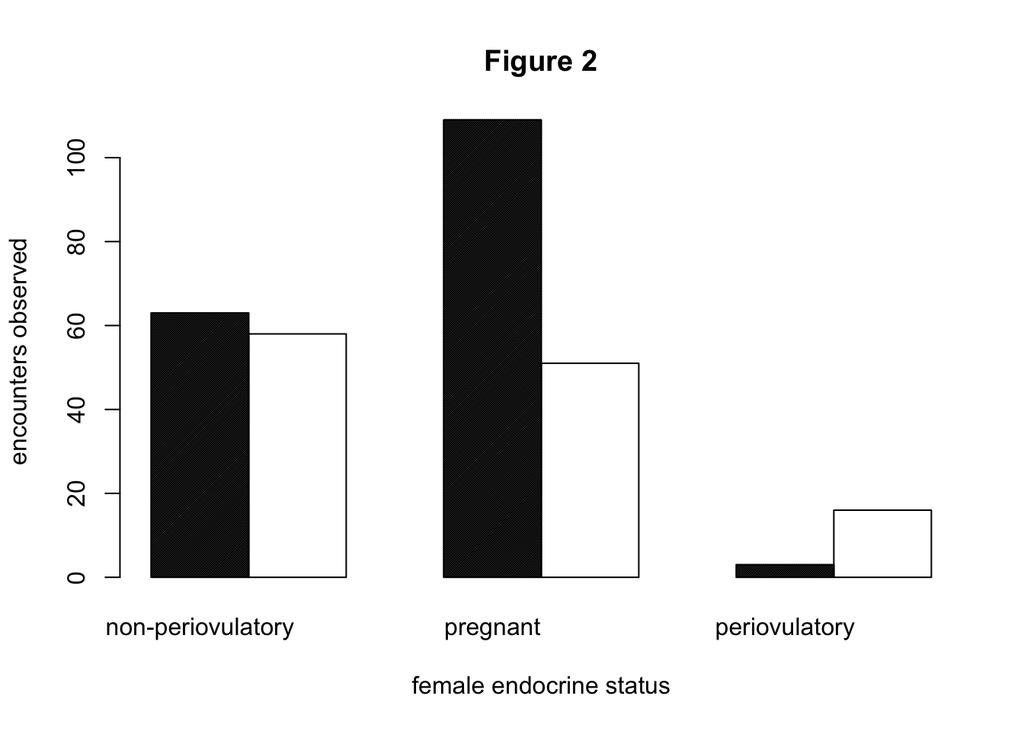

```r
v2 <- c(totalmatings1, totalmatings2, totalmatings3, totalmatings4, totalmatings5, totalmatings6)

barplot(v2, main = "Figure 2", xlab = "female endocrine status", ylab = "encounters observed", names.arg = c("non-periovulatory","non-periovulatory","pregnant","pregnant", "periovulatory", "periovulatory"), col = "black", density = c(100, 0, 100, 0, 100, 0), space = c(1, 0, 1, 0, 1, 0))
```

After trying more iterations of code with both of the files, I noticed a column titled “endomiss” in the original long version of the interactions file. This column is filled in for each interaciton observation with either a “0” or “1”. My best guess is that this indicates whether or not the endocrine data from urine samples is missing or not. “0” would indicate that it is not missing (so the interaction can be used), while “1” would indicate that the endocrine data is missing, and should be excluded from the analysis. I added this into the filter of my original code to see if it would help me.

First, I loaded the original set of data in to R.

```r
library(curl)
f2 <- curl("https://raw.githubusercontent.com/natalierobinson96/data-reanalysis-assignment/master/interactions.csv")
d2 <- read.csv(f2, header = TRUE, sep = ",")
```

Next I created a new dataframe which only includes the observation entries which were included in the final analysis.

```r
d2 <- filter(d2, InteractionwithMale == "Y")
d2 <- filter(d2, included == "1")
d2 <- filter(d2, endomiss == "0")
head(d2) # I got it down to the 153 observations!!
```

```
##    Date day year    year2   DateSPSS      Name     Name2 Record.
## 1 34340   7   94 94.01780 01/07/1994 Elizabeth Elizabeth      31
## 2 34343  10   94 94.02601 01/10/1994 Elizabeth Elizabeth      40
## 3 34309 341   93 93.93292 12/07/1993 Elizabeth Elizabeth     830
## 4 34342   9   94 94.02327 01/09/1994 Elizabeth Elizabeth     879
## 5 34344  11   94 94.02875 01/11/1994 Elizabeth Elizabeth     882
## 6 34380  47   94 94.12731 02/16/1994 Elizabeth Elizabeth     942
##              TypeofInteraction FemaleAgeclass FemaleMotherClass
## 1                     Mating 1   Adult Female            Mother
## 2                  Consortship   Adult Female            Mother
## 3                                Adult Female            Mother
## 4 Female companion consortship   Adult Female            Mother
## 5 Female companion consortship   Adult Female            Mother
## 6                                Adult Female            Mother
##   OffspringClass ObservedReproductiveStatus EndocrineStatusHormones
```

[output cut: 125 more lines]

Finally, this dataframe contains 153 rows – the correct number of observations!

As before, I created the 3 categories of female endocrine status:

```r
nonPOP <- filter(d2, preg == "0" & POP == "0") #matings with females not in periovulatory period; currently cycling
```

```r
pregnant <- filter(d2, preg == "1") #matings with pregnant females
```

```r
POP <- filter(d2, POP == "1") #matings with females in periovulatory period
```

Then I created 6 more variables which will serve as each entry of the replicated bar plot. The 3 female ovulatory statuses stay the same, though they are divided bewtween those who encountered prime males and those who encountered non-prime males (either unflanged or past-prime). For each variable I also counted the number of occurences of encounters by counting the number of rows.

```r
nonPOP_nonprime <- filter(nonPOP, prime == "0")
totalmatings1 <- length(attributes(nonPOP_nonprime)$row.names)
```

```r
nonPOP_prime <- filter(nonPOP, prime == "1")
totalmatings2 <- length(attributes(nonPOP_prime)$row.names)
```

```r
pregnant_nonprime <- filter(pregnant, prime == "0")
totalmatings3 <- length(attributes(pregnant_nonprime)$row.names)
```

```r
pregnant_prime <- filter(pregnant, prime == "1")
totalmatings4 <- length(attributes(pregnant_prime)$row.names)
```

```r
POP_nonprime <- filter(POP, prime == "0")
totalmatings5 <- length(attributes(POP_nonprime)$row.names)
```

```r
POP_prime <- filter(POP, prime == "1")
totalmatings6 <- length(attributes(POP_prime)$row.names)
```

I then created a vector of each of the values of occurences.

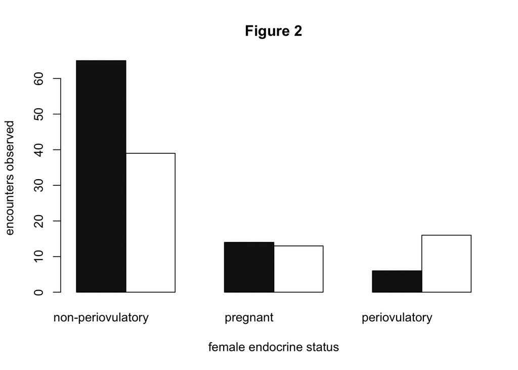

```r
v2 <- c(totalmatings1, totalmatings2, totalmatings3, totalmatings4, totalmatings5, totalmatings6)

barplot(v2, main = "Figure 2", xlab = "female endocrine status", ylab = "encounters observed", names.arg = c("non-periovulatory","non-periovulatory","pregnant","pregnant", "periovulatory", "periovulatory"), col = "black", density = c(100, 0, 100, 0, 100, 0), space = c(1, 0, 1, 0, 1, 0))
```

Again, this is what the figure from the paper looks like:

[figure not shown]

They are the same!

Though the code for creating this graph is simple, the difficult part of replication was sorting through all the data that was sent to me. I was given separate spreadsheets (of various different formats) from different dates containing different data. This made it very difficult to figure out which data I should use for each part of the replication. This has taught me an important lesson for my own future research/data collection. A cleaner/simpler dataset allows less room for error in analysis and is overall more user-friendly.

# Replication 3: Linear Mixed Model Analysis (Inferential)

To make sense of this data, Knott et al. (2010) used a linear mixed model analysis. As explained in the paper, all random effects were intercept only and used female identity as the subject identifier. Male identity was not used to characterize non-independence because male inclusion in the observations was not under researcher control. Additionally, female reproductive status varies substantially more than the male-specific variable of prime vs. non-prime.

For continuous outcomes (such as the number of resistant behaviors observed), the authors used mixed linear models. This was done in an SPSS program called MIXED. The same modelling was done for the association between male and female behavior during mating interactions, though log-transformed variables were used for analysis and were then returned to linear values for reporting of estimates. I will not try to replicate this portion of the modelling.